# Soluciones 2

Sergio Camiz

2025-04-20

```r
options(width = 300)                                        # ancho de página
```

## 1 Construir

*una carpeta Ejercicio__2*

*Hecho*

```r
setwd("/Work/Lavoro/PUCP/Corso PUCP 2025 - Modelo Lineal/Lezioni 2025/Clase_2 - Regresión simple/Esercizi")                            # carpeta de trabajo
```

## 2 Bajar desde Paideia:

SudAmerica.csv, Baseball.csv, Students.csv.

*Hecho*

## 3 Abrir Rstudio

en la carpeta misma con Rmarkdown

*Hecho*

## 4 cargar los archivos

```r
SudAmerica          <-read.csv("SudAmerica.csv",row.names=1) # lectura del archivo
head(SudAmerica)
```

```
##           Tajo_urbano   IDH
## Argentina          86 0.833
## Bolivia            51 0.394
## Brasil             75 0.739
## Chile              86 0.863
## Colombia           70 0.758
## Ecuador            56 0.641
```

```r
Baseball            <-read.csv("Baseball.csv",row.names=1)   # lectura del archivo
head(Baseball)
```

```
##            BattingAvg WinningPerc
## Baltimore       0.266       0.574
## Boston          0.269       0.661
## California      0.256       0.508
## Chicago         0.246       0.410
## Cleveland       0.271       0.500
## Detroit         0.259       0.467
```

```r
Students            <-read.csv("Students.csv",row.names=1)   # lectura del archivo
head(Students)
```

```
##   midterm final   hw total
## 1    24.5  26.0 28.5  79.0
## 2    22.5  24.5 28.2  75.2
## 3    23.5  26.5 28.3  78.3
## 4    23.5  34.5 29.2  87.2
## 5    22.5  30.5 27.3  80.3
## 6    16.0  31.0 27.5  74.5
```

## 5 revisando el conjunto de comandos

en Clase_2.R correr la regresión de IDH con Tajo Urbano

```r
attach(SudAmerica)                          # archivo en uso
lab <- rownames(SudAmerica)                 # etiquetas de las unidades en lab
detach(SudAmerica)
n <- dim(SudAmerica)[1]; n                  # n es el número de observaciones
```

```
## [1] 13
```

```r
x <- SudAmerica[,1]; x                      # x es el caracter descriptivo
```

```
##  [1] 86 51 75 86 70 56 35 54 48 70 48 86 84
```

```r
y <- SudAmerica[,2]; y                      # y es el caracter respuesta
```

```
##  [1] 0.833 0.394 0.739 0.863 0.758 0.641 0.539 0.731 0.637 0.600 0.749 0.880 0.824
```

```r
nom <- colnames(SudAmerica)                 # etiquetas de las variables en nom
# estadísticas
xm <-sum(x)/n; xm                           # cálculo de xm, promedio de x
```

```
## [1] 65.30769
```

```r
ym <-sum(y)/n; ym                           # cálculo de ym, promedio de y
```

```
## [1] 0.7067692
```

```r
ssx <- sum(x^2); ssx                        # ssx es la suma de los x cuadros
```

```
## [1] 59155
```

```r
ssy <- sum(y^2); ssy                        # ssy es la suma de los y cuadros
```

```
## [1] 6.730488
```

```r
sxy <- sum(x*y); sxy                        # sxy es la suma de los productos xy
```

```
## [1] 622.094
```

```r
ssxc <- ssx-n*xm^2 ; ssxc                   # ssxc es ssx centrado sobre el promedio
```

```
## [1] 3708.769
```

```r
ssyc <- ssy-n*ym^2 ; ssyc                   # ssyc es ssy centrado sobre el promedio
```

```
## [1] 0.2366923
```

```r
sxyc <- sxy-n*xm*ym; sxyc                   # sxyc es sxy centrado sobre el promedio
```

```
## [1] 22.04692
```

```r
varx <- ssxc/n; varx                        # varx es la varianza de x
```

```
## [1] 285.2899
```

```r
vary <- ssyc/n; vary                        # vary es la varianza de y
```

```
## [1] 0.0182071
```

```r
covxy <- sxyc/n; covxy                      # covxy es la covarianza de xy
```

```
## [1] 1.695917
```

```r
stats = matrix(24*0,nrow=8,ncol=3)          # construcción de tabla de estadísticas
rownames(stats) = c("Mínimo","Máximo","Promedio","Total","Suma de cuadrados",
                    "Cuadrados centrados","Varianza covarianza","Desvío estándar")
colnames(stats) = c(nom,"xy")
  stats[,1] = rbind(min(x),max(x),xm,sum(x),ssx,ssxc,varx,sqrt(varx))
  stats[,2] = rbind(min(y),max(y),ym,sum(y),ssy,ssyc,vary,sqrt(vary))
  stats[,3] = rbind(0,0,0,0,sxy,sxyc,covxy,0)
  stats                                     # impresión de la tabla
```

```
##                     Tajo_urbano       IDH         xy
## Mínimo                 35.00000 0.3940000   0.000000
## Máximo                 86.00000 0.8800000   0.000000
## Promedio               65.30769 0.7067692   0.000000
## Total                 849.00000 9.1880000   0.000000
## Suma de cuadrados   59155.00000 6.7304880 622.094000
## Cuadrados centrados  3708.76923 0.2366923  22.046923
## Varianza covarianza   285.28994 0.0182071   1.695917
## Desvío estándar        16.89053 0.1349337   0.000000
```

```r
# estimación
bh <- sxyc/ssxc ; bh                        # bh es la estimación de beta
```

```
## [1] 0.005944539
```

```r
ah <- ym - bh*xm ; ah                       # ah es la estimación de alfa
```

```
## [1] 0.3185451
```

```r
paste("IDH = ",ah," + ",bh," * Tajo Urbano",sep="" )
```

```
## [1] "IDH = 0.318545111378437 + 0.00594453893060109 * Tajo Urbano"
```

```r
eta = ah + bh * x; eta                      # valores estimados
```

```
##  [1] 0.8297755 0.6217166 0.7643855 0.8297755 0.7346628 0.6514393 0.5266040 0.6395502 0.6038830 0.7346628 0.6038830 0.8297755 0.8178864
```

```r
res = y - eta; res                          # residuos
```

```
##  [1]  0.003224541 -0.227716597 -0.025385531  0.033224541  0.023337163 -0.010439291  0.012396026  0.091449786  0.033117020 -0.134662837  0.145117020  0.050224541  0.006113618
```

```r
respc = res/y
unidad = cbind(x,y,eta,res,respc)                 # tabla de resultados
rownames(unidad) = lab
colnames(unidad) = c(nom,"eta","residuos","%res")
unidad                                      # impresión de la tabla
```

```
##           Tajo_urbano   IDH       eta     residuos         %res
## Argentina          86 0.833 0.8297755  0.003224541  0.003870997
## Bolivia            51 0.394 0.6217166 -0.227716597 -0.577960906
## Brasil             75 0.739 0.7643855 -0.025385531 -0.034351192
## Chile              86 0.863 0.8297755  0.033224541  0.038498888
## Colombia           70 0.758 0.7346628  0.023337163  0.030787815
## Ecuador            56 0.641 0.6514393 -0.010439291 -0.016285946
## Guyana             35 0.539 0.5266040  0.012396026  0.022998193
## Panama             54 0.731 0.6395502  0.091449786  0.125102307
## Paraguay           48 0.637 0.6038830  0.033117020  0.051989042
## Peru               70 0.600 0.7346628 -0.134662837 -0.224438061
## Suriname           48 0.749 0.6038830  0.145117020  0.193747690
## Uruguay            86 0.880 0.8297755  0.050224541  0.057073342
## Venezuela          84 0.824 0.8178864  0.006113618  0.007419440
```

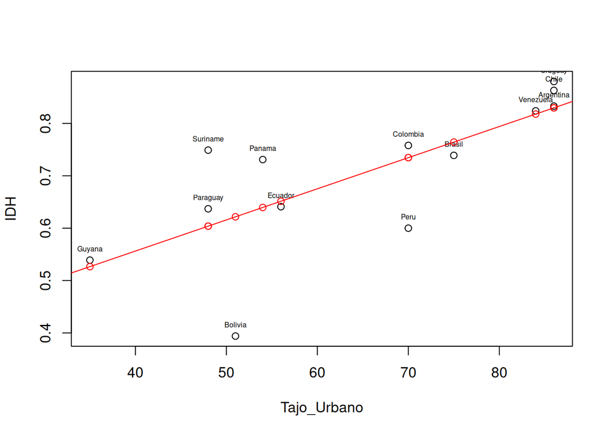

```r
#
# gráfico clásico
plot(x,y,xlab="Tajo_Urbano",ylab="IDH")
text(x,y,labels=lab, cex = 0.5, pos=3)
points(x,eta,col="red")
abline(ah,bh,col="red")
```

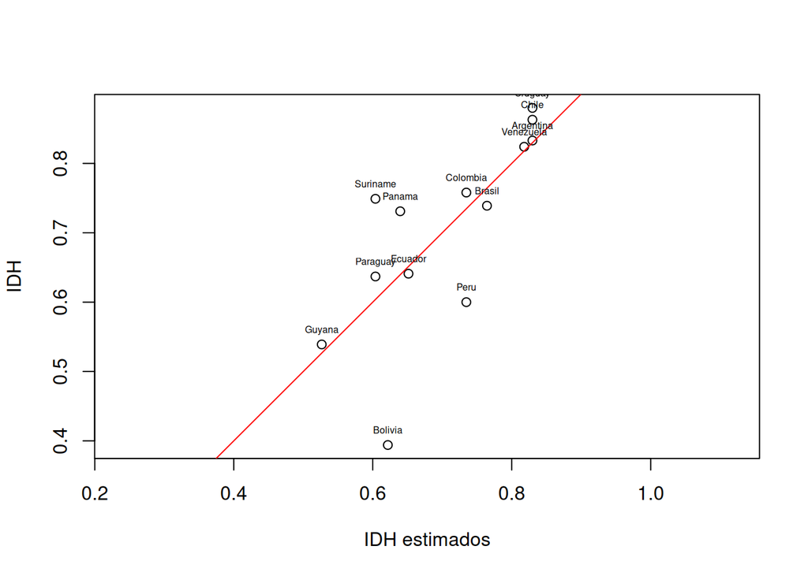

```r
# gráficos de valores estimados y residuos
plot(eta,y,asp=1,xlab="IDH estimados",ylab="IDH")
abline(0,1,col="red")
text(eta,y,labels=lab, cex = 0.5, pos=3)
```

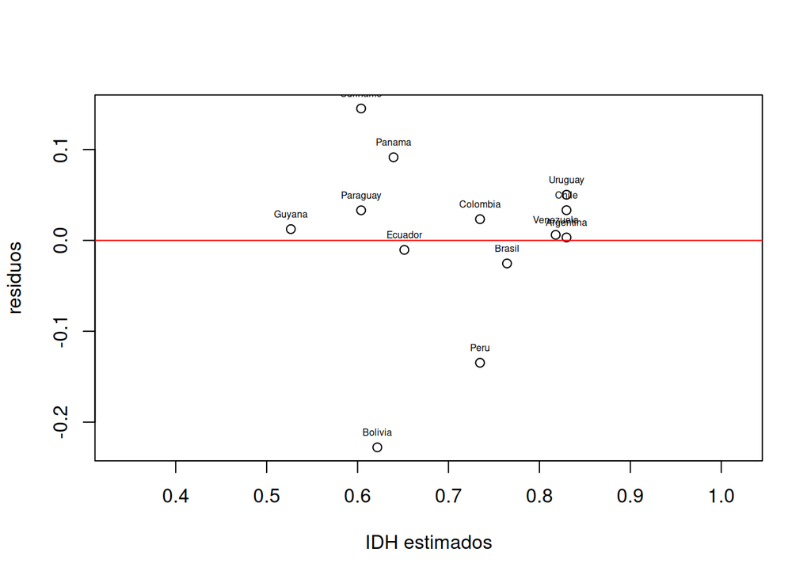

```r
plot(eta,res,asp=1,xlab="IDH estimados",ylab="residuos")
abline(0,0,col="red")
text(eta,res,labels=lab, cex = 0.5, pos=3)
```

## 6 Realizar una función

que tome en entrada regresor y criterio y salen los resultados. Se haga de manera que salgan también pesos, pendientes, y apalancamiento del regresor.

```r
reg_simple          <- function(y,x,lab) {
  res               <- list()
  n                 <- length(y)                            # número de observaciones
  # estadísticas
  xm                <- sum(x)/n                             # cálculo del promedio de x
  ym                <- sum(y)/n                             # cálculo del promedio de y
  ssx               <- sum(x^2)                             # suma de los x cuadros
  ssy               <- sum(y^2)                             # suma de los y cuadros
  sxy               <- sum(x*y)                             # suma de los productos xy
  ssxc              <- ssx-n*xm^2                           # ssx centrado
  ssyc              <- ssy-n*ym^2                           # ssy centrado
  sxyc              <- sxy-n*xm*ym                          # sxy centrado
  varx              <- ssxc/n                               # varianza de x
  vary              <- ssyc/n                               # varianza de y
  covxy             <- sxyc/n                               # covarianza de xy
  # construcción de tabla de estadísticas
  stats             <- matrix(24*0,nrow=8,ncol=3)
  stats[,1]         <- rbind(min(x),max(x),xm,sum(x),ssx,ssxc,varx,sqrt(varx))
  stats[,2]         <- rbind(min(y),max(y),ym,sum(y),ssy,ssyc,vary,sqrt(vary))
  stats[,3]         <- rbind(0,0,0,0,sxy,sxyc,covxy,0)
  rownames(stats)   <- c("Mínimo","Máximo","Promedio",
                         "Total","Suma de cuadrados",
                         "Cuadrados centrados",
                         "Varianza covarianza",
                         "Desviación estándar")
  colnames(stats)   <- c("x","y","xy")
  res$statistics    <- round(stats,3)                       # impresión de la tabla
  # estimación
  bh                <- sxyc/ssxc                            # estimación de beta
  ah                <- ym - bh*xm                           # estimación de alfa
  coef              <- c(ah,bh)
  names(coef)       <- c("alpha","beta")
  res$parameters    <- coef
  eta               <- ah + bh * x                          # valores estimados
  resid             <- y - eta;                             # residuos
  respc             <- resid/y                              # residuos en porcentaje
  unidad            <- cbind(x,y,eta,resid,respc)           # tabla de resultados
  rownames(unidad)  <- lab
  colnames(unidad)  <- c("x","y","eta","residuals","%res")
  res$units         <- round(unidad,3)                      # impresión de la tabla
# apalancamiento
  w                 <- (x-xm)^2 / ssxc                      # w pesos de los pendientes
  b                 <- (y-ym)/(x-xm)                        # pendientes
  c                 <- (x-xm) / ssxc                        # coeficientes de beta según y
  Hs                <- matrix(0,n,n,dimnames=list(lab,lab)) # H sombrero
  for (i in 1:n) {
    for (j in 1:n) {
      Hs[i,j]       <- 1 / n + c[j] * (x[i] - xm)
    }
  }
  lev               <- diag(Hs) + 1/n                       # apalancamientos
  pesos             <- cbind(x,w,b,y,c,lev)                 # tabla de pesos
  rownames(pesos)   <- lab
  colnames(pesos)   <- c("x","weight","slope","y","cii","leverage")
  res$weights       <- round(pesos,3)                       # salida

  # gráfico clásico
  plot(x,y,xlab="regressor",ylab="criterion")               # grafico
    text(x,y,labels=lab, cex = 0.5, pos=3)                  # etiquetas
    points(x,eta,col="red")                                 # predictos
    abline(ah,bh,col="red")                                 # recta de regresion

  # gráficos de valores estimados y residuos
  plot(eta,y,asp=1,xlab="fitted",ylab="observed")           # grafico
    abline(0,1,col="red")                                   # diagonal
    text(eta,y,labels=lab, cex = 0.5, pos=3)                # etiquetas

  plot(eta,resid,asp=1,xlab="fitted",ylab="residuals")
    abline(0,0,col="red")
    text(eta,resid,labels=lab, cex = 0.5, pos=3)
  res
}
```

```r
extreme             <- function(reg) {
  mlev              <- which(reg$weights[,6]==max(reg$weights[,6])) # max apalancamiento
  mslo              <- which(abs(reg$weights[,3])==max(abs(reg$weights[,3]))) # max pendiente
  # salida
  extr              <- data.frame(name = rownames(reg$units)[c(mlev,mslo)],
                                  position = c(mlev,mslo),
                                  value = round(c(reg$weights[mlev,6],
                                                  reg$weights[mslo,3]),3))
  nlev              <- length(mlev)
  nslo              <- length(mslo)
  rownames(extr)    <- c("leverage",rep("",nlev-1),"slope",rep("",nslo-1))
  extr
}
```

## 7 aplicar a SudAmerica

para averiguar que todo funciona

### 7.1 Datos SudAmerica

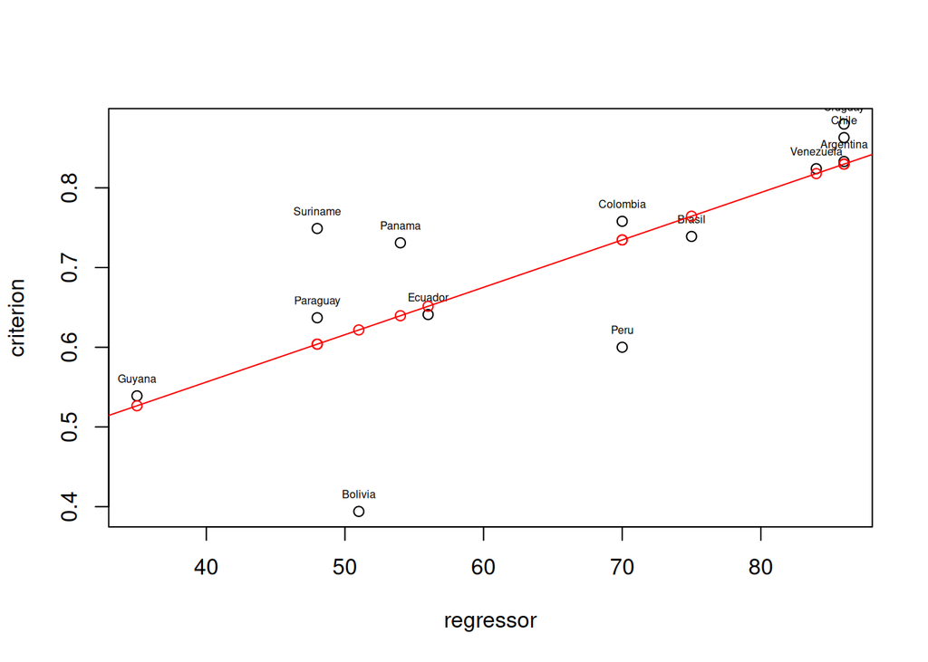

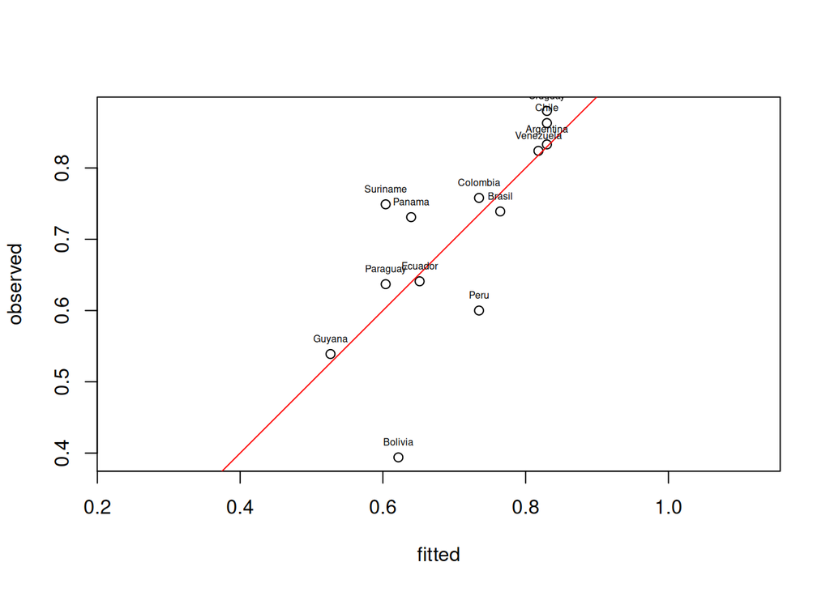

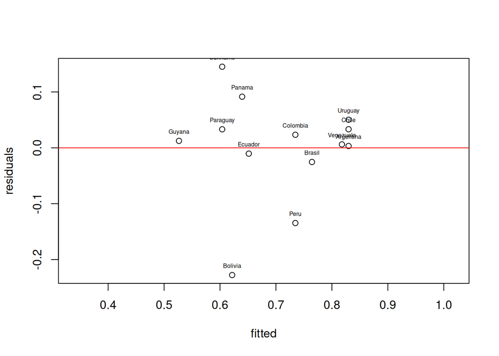

```
## $statistics
##                             x     y      xy
## Mínimo                 35.000 0.394   0.000
## Máximo                 86.000 0.880   0.000
## Promedio               65.308 0.707   0.000
## Total                 849.000 9.188   0.000
## Suma de cuadrados   59155.000 6.730 622.094
## Cuadrados centrados  3708.769 0.237  22.047
## Varianza covarianza   285.290 0.018   1.696
## Desviación estándar    16.891 0.135   0.000
##
## $parameters
##       alpha        beta
## 0.318545111 0.005944539
##
## $units
##            x     y   eta residuals   %res
## Argentina 86 0.833 0.830     0.003  0.004
## Bolivia   51 0.394 0.622    -0.228 -0.578
## Brasil    75 0.739 0.764    -0.025 -0.034
## Chile     86 0.863 0.830     0.033  0.038
## Colombia  70 0.758 0.735     0.023  0.031
## Ecuador   56 0.641 0.651    -0.010 -0.016
## Guyana    35 0.539 0.527     0.012  0.023
## Panama    54 0.731 0.640     0.091  0.125
## Paraguay  48 0.637 0.604     0.033  0.052
## Peru      70 0.600 0.735    -0.135 -0.224
## Suriname  48 0.749 0.604     0.145  0.194
## Uruguay   86 0.880 0.830     0.050  0.057
## Venezuela 84 0.824 0.818     0.006  0.007
##
## $weights
##            x weight  slope     y    cii leverage
## Argentina 86  0.115  0.006 0.833  0.006    0.269
## Bolivia   51  0.055  0.022 0.394 -0.004    0.209
## Brasil    75  0.025  0.003 0.739  0.003    0.179
## Chile     86  0.115  0.008 0.863  0.006    0.269
## Colombia  70  0.006  0.011 0.758  0.001    0.160
## Ecuador   56  0.023  0.007 0.641 -0.003    0.177
## Guyana    35  0.248  0.006 0.539 -0.008    0.402
## Panama    54  0.034 -0.002 0.731 -0.003    0.188
## Paraguay  48  0.081  0.004 0.637 -0.005    0.235
## Peru      70  0.006 -0.023 0.600  0.001    0.160
## Suriname  48  0.081 -0.002 0.749 -0.005    0.235
## Uruguay   86  0.115  0.008 0.880  0.006    0.269
## Venezuela 84  0.094  0.006 0.824  0.005    0.248
```

```r
(SudAm.reg          <- reg_simple(y=SudAmerica$IDH,x=SudAmerica$Tajo_urbano
                                  ,lab=rownames(SudAmerica)))
```

```r
(SudAm.ext          <- extreme(SudAm.reg))
```

```
##            name position  value
## leverage Guyana        7  0.402
## slope      Peru       10 -0.023
```

Se encuentran países muy cerca de la recta, como Argentina, Venezuela, Ecuador y Guyana, otro como Perú, Suriname e sobre todo Bolivia bastante alajados.

Se resulta Guyana el país con el máximo de apalancamiento y Perú con el máximo pendiente.

### 7.2 Baseball

```
Baseball:  modelar WinningPerc utilizando BattingAvg
```

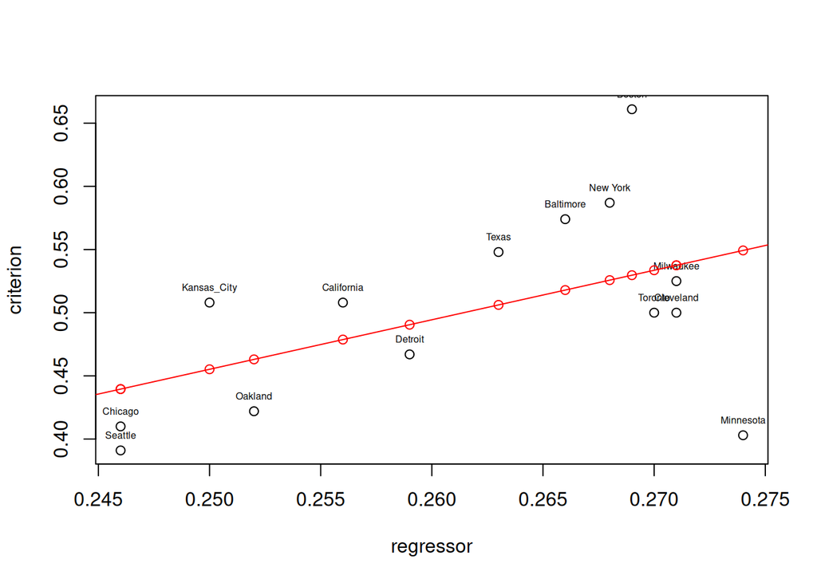

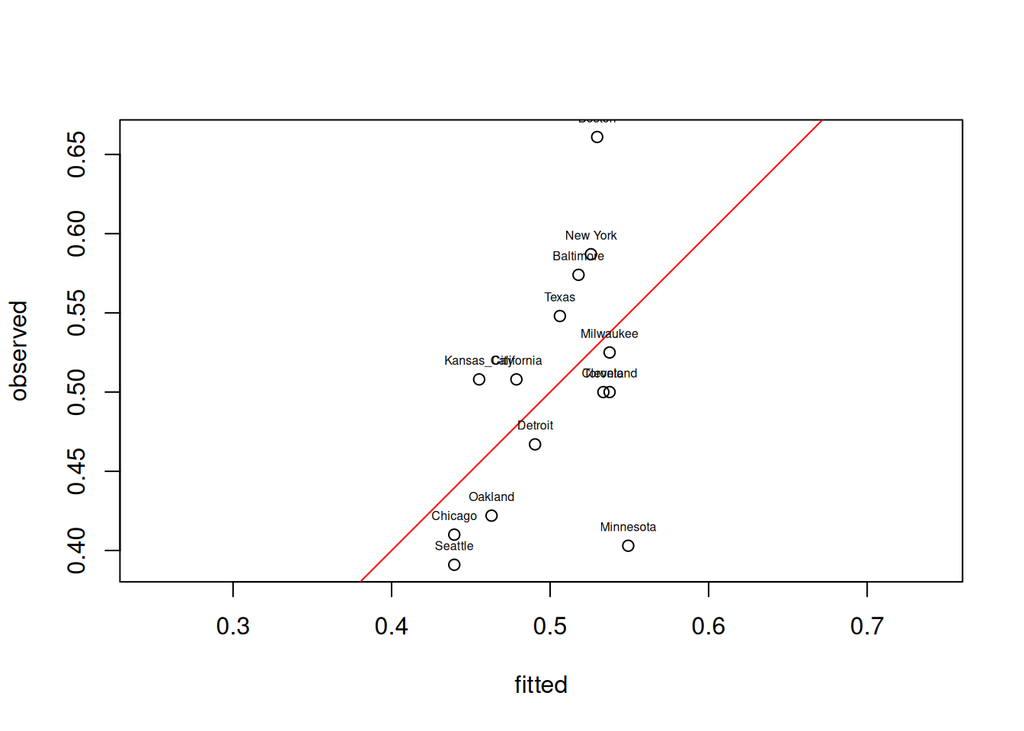

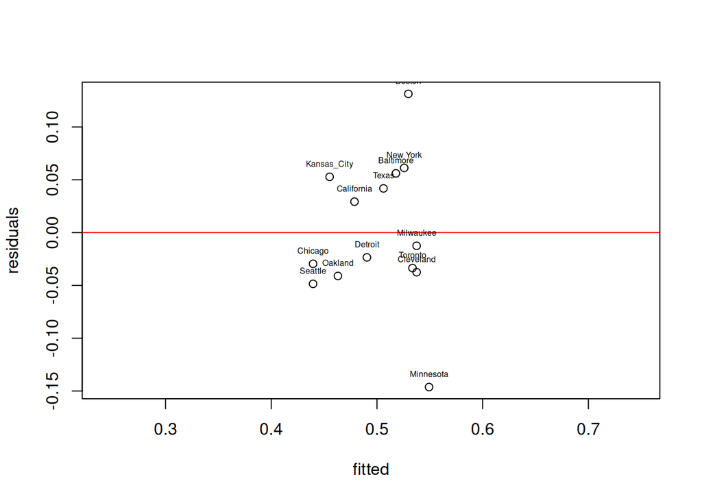

```
## $statistics
##                         x     y    xy
## Mínimo              0.246 0.391 0.000
## Máximo              0.274 0.661 0.000
## Promedio            0.262 0.500 0.000
## Total               3.661 7.004 0.000
## Suma de cuadrados   0.959 3.583 1.837
## Cuadrados centrados 0.001 0.079 0.005
## Varianza covarianza 0.000 0.006 0.000
## Desviación estándar 0.010 0.075 0.000
##
## $parameters
##      alpha       beta
## -0.5244977  3.9188657
##
## $units
##                 x     y   eta residuals   %res
## Baltimore   0.266 0.574 0.518     0.056  0.098
## Boston      0.269 0.661 0.530     0.131  0.199
## California  0.256 0.508 0.479     0.029  0.058
## Chicago     0.246 0.410 0.440    -0.030 -0.072
## Cleveland   0.271 0.500 0.538    -0.038 -0.075
## Detroit     0.259 0.467 0.490    -0.023 -0.050
## Kansas_City 0.250 0.508 0.455     0.053  0.104
## Milwaukee   0.271 0.525 0.538    -0.013 -0.024
## Minnesota   0.274 0.403 0.549    -0.146 -0.363
## New York    0.268 0.587 0.526     0.061  0.104
## Oakland     0.252 0.422 0.463    -0.041 -0.097
## Seattle     0.246 0.391 0.440    -0.049 -0.124
## Texas       0.263 0.548 0.506     0.042  0.076
## Toronto     0.270 0.500 0.534    -0.034 -0.067
##
## $weights
##                 x weight  slope     y     cii leverage
## Baltimore   0.266  0.016 16.381 0.574   3.545    0.159
## Boston      0.269  0.044 21.429 0.661   5.908    0.187
## California  0.256  0.024 -1.403 0.508  -4.332    0.167
## Chicago     0.246  0.189  5.825 0.410 -12.210    0.332
## Cleveland   0.271  0.071 -0.030 0.500   7.483    0.214
## Detroit     0.259  0.005 13.314 0.467  -1.969    0.148
## Kansas_City 0.250  0.104 -0.671 0.508  -9.059    0.247
## Milwaukee   0.271  0.071  2.602 0.525   7.483    0.214
## Minnesota   0.274  0.123 -7.783 0.403   9.846    0.266
## New York    0.268  0.033 13.341 0.587   5.120    0.176
## Oakland     0.252  0.071  8.241 0.422  -7.483    0.214
## Seattle     0.246  0.189  7.051 0.391 -12.210    0.332
## Texas       0.263  0.002 31.810 0.548   1.182    0.145
## Toronto     0.270  0.057 -0.034 0.500   6.696    0.200
```

```r
(Base.reg           <- reg_simple(y=Baseball$WinningPerc,x=Baseball$BattingAvg,
                                  lab=rownames(Baseball)))
```

```r
(Base.ext           <- extreme(Base.reg))
```

```
##             name position  value
## leverage Chicago        4  0.332
##          Seattle       12  0.332
## slope      Texas       13 31.810
```

Ningun equipo se encuentra sobre la recta. Los más lejanos son Boston y Minnesota. Dos equipos tienen apalancamiento fuerte: Chicago y Seattle, mientras el máximo de pendiente resulta Texas.

### 7.3 Students: modelar final con midterm

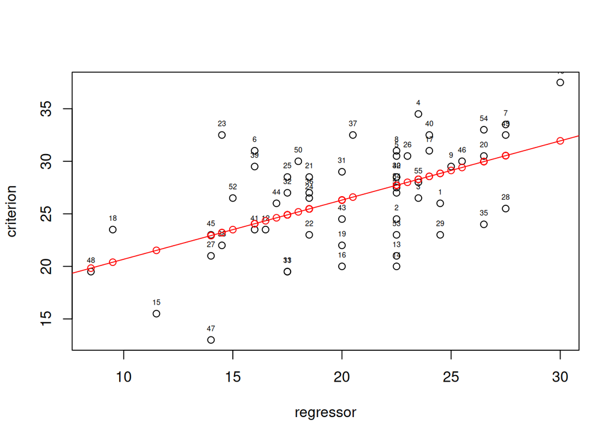

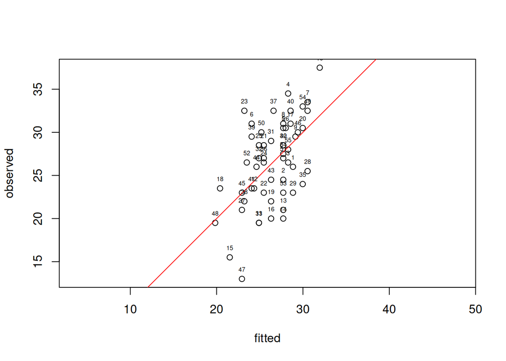

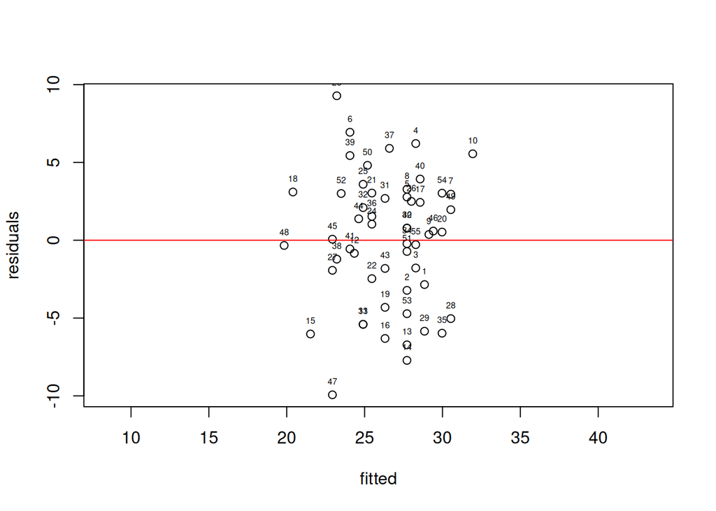

```
## $statistics
##                             x         y        xy
## Mínimo                  8.500    13.000     0.000
## Máximo                 30.000    37.500     0.000
## Promedio               20.318    26.491     0.000
## Total                1117.500  1457.000     0.000
## Suma de cuadrados   23947.250 39922.500 30303.000
## Cuadrados centrados  1241.682  1325.245   699.409
## Varianza covarianza    22.576    24.095    12.717
## Desviación estándar     4.751     4.909     0.000
##
## $parameters
##      alpha       beta
## 15.0461727  0.5632756
##
```

[output cut: 115 more lines]

```r
(Stud.reg           <- reg_simple(y=Students$final,x=Students$midterm,
                                  lab=rownames(Students)))
```

```r
(Stud.ext           <- extreme(Stud.reg))
```

```
##          name position  value
## leverage   48       48  0.149
## slope      37       37 33.050
```

## 8 Sobre los tres archivos,

correr con lm() los modelos, el modelo sin intercepta (se escribe “criterio ~ regresor -1”), el modelo con intercepta pero tirando la unidad con mayor apalancamiento y la unidad con mayor pendiente.

Representar en gráfico las cuatro rectas conseguidas.

### 8.1 SudAmerica

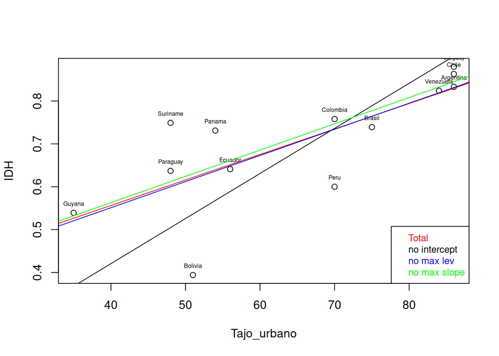

```r
attach(SudAmerica)
SudAm.lm1           <- lm(IDH~Tajo_urbano, data=SudAmerica)   # completa
SudAm.lm2           <- lm(IDH~Tajo_urbano-1, data=SudAmerica) # sin alfa
SudAm.lm3           <- lm(IDH~Tajo_urbano,
                          data=SudAmerica[-SudAm.ext[1,2],])  # sin apalancamiento
SudAm.lm4           <- lm(IDH~Tajo_urbano,
                          data=SudAmerica[-SudAm.ext[2,2],])  # sin pendiente
plot(Tajo_urbano,IDH,xlab="Tajo_urbano",ylab="IDH")         # grafico
    text(Tajo_urbano,IDH,labels=rownames(SudAmerica),
         cex = 0.5, pos=3)                                  # etiquetas
    abline(SudAm.lm1$coefficients,col="red")                # total
    abline(0,SudAm.lm2$coefficients,col="black")            # sin alfa
    abline(SudAm.lm3$coefficients,col="blue")               # sin apalancamiento
    abline(SudAm.lm4$coefficients,col="green")              # sin pendiente
    legend("bottomright",legend=c("Total","no intercept","no max lev","no max slope"),
           text.col=c("red","black","blue","green"),cex=0.8)
```

```r
detach(SudAmerica)
```

La mayor diferencia se encuentra en la regresión sin intercepta, la sin máximo pendiente sendo poco destacada de las demás. La sin máximo apalancamiento es muy poco rodada de la total.

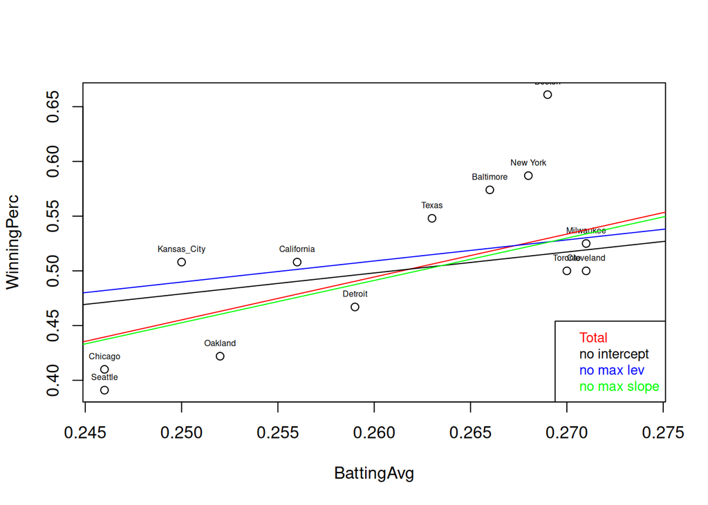

```r
attach(Baseball)
Base.lm1           <- lm(WinningPerc~BattingAvg, data=Baseball)   # completa
Base.lm2           <- lm(WinningPerc~BattingAvg-1, data=Baseball) # sin alfa
Base.lm3           <- lm(WinningPerc~BattingAvg,
                          data=Baseball[-Base.ext[c(1,2),2],])    # sin apalancamiento
Base.lm4           <- lm(WinningPerc~BattingAvg,
                          data=Baseball[-Base.ext[3,2],])         # sin pendiente
plot(BattingAvg,WinningPerc,xlab="BattingAvg",ylab="WinningPerc") # grafico
    text(BattingAvg,WinningPerc,labels=rownames(Baseball),
         cex = 0.5, pos=3)                                  # etiquetas
    abline(Base.lm1$coefficients,col="red")                 # total
    abline(0,Base.lm2$coefficients,col="black")             # sin alfa
    abline(Base.lm3$coefficients,col="blue")                # sin apalancamiento
    abline(Base.lm4$coefficients,col="green")               # sin pendiente
    legend("bottomright",legend=c("Total","no intercept","no max lev","no max slope"),
           text.col=c("red","black","blue","green"),cex=0.8)
```

```r
detach(Baseball)
```

En este caso la mayor diferencia se encuentra en la regresión sin máximos apalancamientos, ya que son dos unidades, con una rotación parecida a la regresión sin intercepta. la sin máximo pendiente es muy parecida a la total.

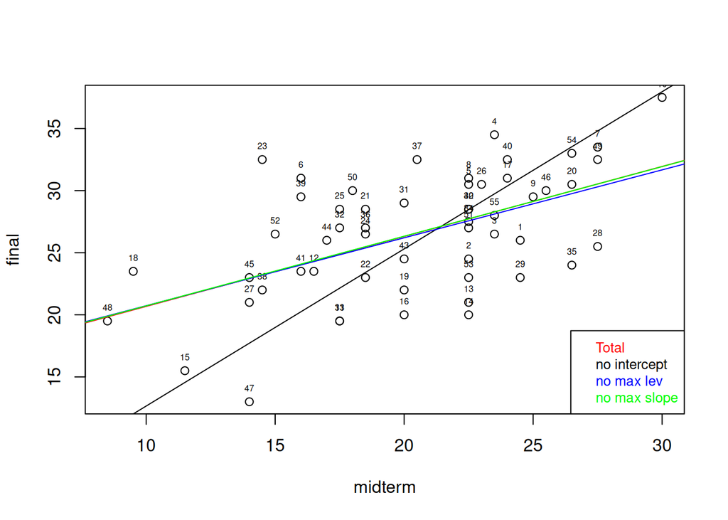

```r
attach(Students)
Stud.lm1           <- lm(final~midterm, data=Students)      # completa
Stud.lm2           <- lm(final~midterm-1, data=Students)    # sin alfa
Stud.lm3           <- lm(final~midterm,
                          data=Students[-Base.ext[1,2],])   # sin apalancamiento
Stud.lm4           <- lm(final~midterm,
                          data=Students[-Base.ext[2,2],])   # sin pendiente
plot(midterm,final,xlab="midterm",ylab="final")             # grafico
    text(midterm,final,labels=rownames(Students),
         cex = 0.5, pos=3)                                  # etiquetas
    abline(Stud.lm1$coefficients,col="red")                 # total
    abline(0,Stud.lm2$coefficients,col="black")             # sin alfa
    abline(Stud.lm3$coefficients,col="blue")                # sin apalancamiento
    abline(Stud.lm4$coefficients,col="green")               # sin pendiente
    legend("bottomright",legend=c("Total","no intercept","no max lev","no max slope"),
           text.col=c("red","black","blue","green"),cex=0.8)
```

```r
detach(Students)
```

## 10 guardar los archivos

.Rmd y .html y enviar-los a sergio@camiz.it antes de las 23:59 del 21 de Abril.